# Untitled

```r
library(dplyr)
```

```r
library(ggplot2)
data = read.csv('/Users/jialew/Desktop//¸½¼þ1/LIME_files/6207229_Z2A8J6HQ.csv')
da<-data
a<-strptime(data$Trip.Completed.At,"%Y-%m-%d %H:%M:%S")
b.1<-data$Trip.Started.At
b<-strptime(b.1,"%Y-%m-%d %H:%M:%S")
b<-as.Date(b)
da$s.m<-as.numeric(format(b,"%m"))
da$s.d<-as.numeric(format(b,"%d"))
da$s.h<-as.numeric(format(b,"%H"))
da$c.m<-as.numeric(format(a,"%m"))
da$c.d<-as.numeric(format(a,"%d"))
da$c.h<-as.numeric(format(a,"%H"))
#list day of week
da$dayofweek<-weekdays(a)
#time diff
da$completetime<-as.POSIXct(strptime(data$Trip.Completed.At,format="%Y-%m-%d %H:%M:%S"))
da$starttime<-as.POSIXct(strptime(data$Trip.Started.At,format="%Y-%m-%d %H:%M:%S"))
da$timediff<-difftime(da$completetime,da$starttime,units="secs")
```

```r
#<10, mile>1, 10/5-10/26
g<-da[which(da$Trip.Distance..Meters.>1609 & da$c.m==10 & da$c.d>4 & da$c.d<27 & da$s.h<10),]
table(g$City.Name)
```

```
##
##  Eastville Northville  Westville
##        202         29         17
```

```r
#user usage increase in 2nd month
#most used vehicle id
carid.freq<-table(da$Vehicle.ID)


length(da[which(da$c.m==10),"Rider.ID"])-length(da[which(da$c.m==9),"Rider.ID"])
```

```
## [1] 520
```

```r
daa<-table(da$Vehicle.ID)
max(daa)
```

```
## [1] 4
```

```r
length(unique(da$Vehicle.ID)) #1855
```

```
## [1] 1855
```

```r
h<-da[which(da$c.m<=11 & da$c.d>4 & da$c.d<27 & da$s.h<10),]
```

1. How many users in Sep used it again in Oct

```r
#user in sep
septuser<-da %>% filter(c.m==9)
#user in oct
octuser<-da %>% filter(c.m==10)

#recurring user
recur<-length(intersect(septuser,octuser))
#proportion of them in Oct users
print(recur)
```

```
## [1] 26
```

```r
paste(round(recur/length(octuser)*100,3),"%", sep=" ")
```

```
## [1] "100 %"
```

2. What 1-hour period is the most active hour in terms of usage across all days

```r
daa<-da[,c(3:6,17:22)]
daa2<-as.data.frame(daa %>% group_by(c.h) %>% summarise(tripshour=length(Trip.ID)))
colnames(daa2)<-c("Hour","TripsCompleted")
daa2
```

```
##    Hour TripsCompleted
## 1     0            167
## 2     1            159
## 3     2            126
## 4     3            111
## 5     4            119
## 6     5             97
## 7     6             53
## 8     7             47
## 9     8             26
## 10    9             10
## 11   10             15
## 12   11             10
## 13   12             11
## 14   13             24
## 15   14             38
## 16   15             41
## 17   16             62
## 18   17             98
## 19   18            108
## 20   19            150
## 21   20            142
## 22   21            159
## 23   22            161
## 24   23            166
```

```r
str(daa2)
```

```
## 'data.frame':    24 obs. of  2 variables:
##  $ Hour          : num  0 1 2 3 4 5 6 7 8 9 ...
##  $ TripsCompleted: int  167 159 126 111 119 97 53 47 26 10 ...
```

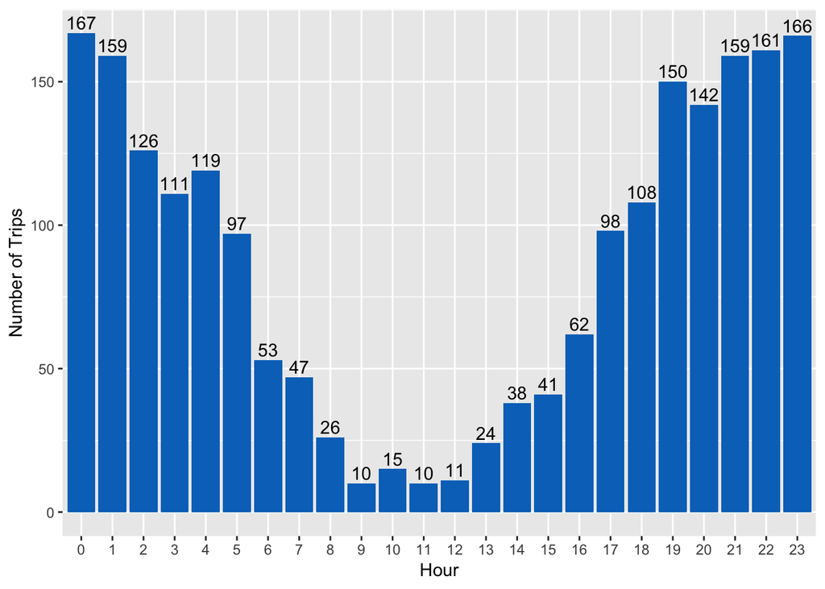

```r
daa2$Hour<-as.factor(daa2$Hour)
ggplot(daa2, aes(x = daa2$Hour, y = daa2$TripsCompleted)) +
  geom_bar(fill = "#0073C2FF", stat = "identity") +
  geom_text(aes(label = daa2$TripsCompleted), vjust = -0.3) + labs(x="Hour") + labs(y="Number of Trips")
```

3. What 1-hour period is the most active hour for each of (Mon/Tue/Wed…Sun)

```r
da$Trip.Completed.At<-as.Date(da$Trip.Completed.At)

da2<-as.data.frame(da %>% group_by(dayofweek,c.h) %>% summarise(tripshour=length(Trip.ID)))
day_activehour<-da2 %>% group_by(dayofweek) %>% summarise(Trips=max(tripshour))
a1<-subset(da2,tripshour==25 & dayofweek=="Friday") #19
a2<-subset(da2,tripshour==39 & dayofweek=="Monday") #0
a3<-subset(da2,tripshour==45 & dayofweek=="Saturday") #23
a4<-subset(da2,tripshour==38 & dayofweek=="Sunday") #22
a5<-subset(da2,tripshour==26 & dayofweek=="Thursday") #1
a6<-subset(da2,tripshour==24 & dayofweek=="Tuesday") #22
a7<-subset(da2,tripshour==22 & dayofweek=="Wednesday") #20
activehour_day<-rbind(a2,a6,a7,a5,a1,a3,a4)
colnames(activehour_day)<-c("Day of Week", "Hour", "Trips")
```

4. What 1-hour period is the most active in weekdays

```r
da3<-as.data.frame(da %>% filter(dayofweek != "Saturday" &dayofweek != "Sunday") %>% group_by(c.h) %>% summarise(tripshour=length(Trip.ID)))
da3
```

```
##    c.h tripshour
## 1    0       111
## 2    1       111
## 3    2        83
## 4    3        71
## 5    4        75
## 6    5        56
## 7    6        32
## 8    7        23
## 9    8        16
## 10   9         5
## 11  10         7
## 12  11         1
## 13  12        10
## 14  13        20
## 15  14        27
## 16  15        35
## 17  16        37
## 18  17        64
## 19  18        69
## 20  19       103
## 21  20       101
## 22  21        88
## 23  22        99
## 24  23        88
```

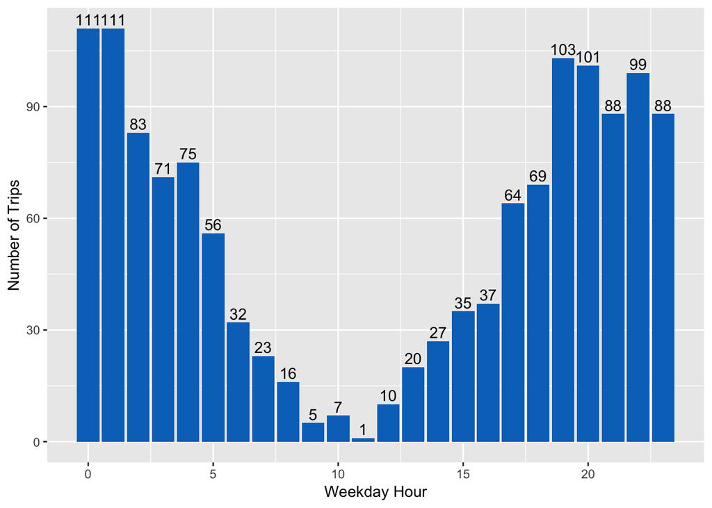

```r
da4<-as.data.frame(da %>% filter(dayofweek == "Saturday" | dayofweek == "Sunday") %>% group_by(c.h) %>% summarise(tripshour=length(Trip.ID)))

#0,1
da3$tripshour<-as.numeric(da3$tripshour)
ggplot(da3, aes(x = da3$c.h, y = da3$tripshour)) +
  geom_bar(fill = "#0073C2FF", stat = "identity") +
  geom_text(aes(label = da3$tripshour), vjust = -0.3) + labs(x="Weekday Hour") + labs(y="Number of Trips")
```

5. Which city has the longest average trip length, which one has the lowest

```r
da %>% group_by(City.Name) %>% summarise(average_distance=mean(Trip.Distance..Meters.))
```

```
## # A tibble: 3 x 2
##   City.Name  average_distance
##   <fct>                 <dbl>
## 1 Eastville             1462.
## 2 Northville            1854.
## 3 Westville             2845.
```

6. Which city generates the most average ride revenue over weekends

```r
str(da$dayofweek)
```

```
##  chr [1:2100] "Saturday" "Saturday" "Sunday" "Saturday" "Wednesday" ...
```

```r
da %>% filter(dayofweek == "Saturday"|dayofweek == "Sunday") %>% group_by(City.Name) %>% summarize(avg_rev_weekends=round(sum(Trip.Amount.Paid..Cents.)/length(Trip.ID)/100,2))
```

```
## # A tibble: 3 x 2
##   City.Name  avg_rev_weekends
##   <fct>                 <dbl>
## 1 Eastville              4.13
## 2 Northville             4.51
## 3 Westville              4.95
```

```r
result7<-as.data.frame(da %>% filter(dayofweek == "Saturday"|dayofweek == "Sunday") %>% group_by(City.Name) %>% summarize(avg_per.ride.rev_weekends=round(sum(Trip.Amount.Paid..Cents.)/length(Trip.ID)/100,2)))
result7$avg_per.ride.rev_weekends<-paste("$",result7$avg_per.ride.rev_weekends, sep=" ")
result7
```

```
##    City.Name avg_per.ride.rev_weekends
## 1  Eastville                    $ 4.13
## 2 Northville                    $ 4.51
## 3  Westville                    $ 4.95
```

7. Which city sees the most ride growth in Oct comparing to Sep? Revenue growth?

```r
#ridegrowth
octtrips<-as.data.frame(da %>% filter(c.m==10) %>% group_by(City.Name) %>% summarise(totaltrips=length(Trip.ID)))
septrips<-as.data.frame(da %>% filter(c.m==9) %>% group_by(City.Name) %>% summarise(totaltrips=length(Trip.ID)))
result8<-as.data.frame(octtrips[,2]-septrips[,2])
rownames(result8)<-unique(unlist(da$City.Name))
colnames(result8)<-c("Sept/Oct Rider Growth")
result8$`Sept/Oct Rider Growth`<-paste(round((result8$`Sept/Oct Rider Growth`/septrips[,2])*100,2),"%",sep=" ")
result8
```

```
##            Sept/Oct Rider Growth
## Eastville                55.09 %
## Northville              266.67 %
## Westville               246.67 %
```

```r
#revgrowth

names(da)
```

```
##  [1] "Country.Code"                   "Timezone"
##  [3] "City.Name"                      "Trip.ID"
##  [5] "Rider.ID"                       "Vehicle.ID"
##  [7] "Vehicle.Type"                   "Trip.Started.At"
##  [9] "Trip.Completed.At"              "Trip.Status"
## [11] "Trip.Distance..Meters."         "Trip.Amount.Paid..Cents."
## [13] "Trip.Amount.Total.Cost..Cents." "Currency"
## [15] "Promotion.ID"                   "Trip.Rating"
## [17] "s.m"                            "s.d"
## [19] "s.h"                            "c.m"
## [21] "c.d"                            "c.h"
## [23] "dayofweek"                      "completetime"
## [25] "starttime"                      "timediff"
```

```r
octrev<-as.data.frame(da %>% filter(c.m==10) %>% group_by(City.Name) %>% summarise(totalrev=sum(Trip.Amount.Paid..Cents.)))
seprev<-as.data.frame(da %>% filter(c.m==9) %>% group_by(City.Name) %>% summarise(totalrev=sum(Trip.Amount.Paid..Cents.)))
results8.1<-as.data.frame(octrev[,2]-seprev[,2])
rownames(results8.1)<-unique(unlist(da$City.Name))
colnames(results8.1)<-c("Sept/Oct Revenue Growth")
results8.1$`Sept/Oct Revenue Growth`<-paste(round((results8.1$`Sept/Oct Revenue Growth`
                                                     /seprev[,2])*100,2),"%",sep=" ")
results8.1
```

```
##            Sept/Oct Revenue Growth
## Eastville                   1.24 %
## Northville                422.22 %
## Westville                 241.43 %
```

8 If we categorize trips as (short trips) < 1000m, mid-trips 1000 <= < 2500, long-trips >= 2500 Make a table for number of rides, avg. distance, avg. rating, avg. cost, avg. ride time for these three cat.

```r
da$timediff<-as.numeric(da$timediff)
short<-subset(da,da$Trip.Distance..Meters.<1000)
mid<-subset(da,da$Trip.Distance..Meters.<2500&da$Trip.Distance..Meters.>=1000)
long<-subset(da,da$Trip.Distance..Meters.>=2500)
#avg cost per min, avg cost per 1000m
index<-which(da$Trip.Amount.Total.Cost..Cents.==0)
da$Trip.Amount.Total.Cost..Cents.[index]<-NA
index2<-which(da$Trip.Distance..Meters.==0)
da$Trip.Amount.Total.Cost..Cents.[index2]<-NA

a1<-c(length(short$Trip.ID),
      mean(short$Trip.Distance..Meters.),
      mean(na.omit(short$Trip.Rating)),
      round(mean(na.omit(short$Trip.Amount.Total.Cost..Cents.))/100,2),
      mean(short$timediff),
      mean(na.omit(short$Trip.Amount.Total.Cost..Cents.)/(short$timediff/60)), mean(mean(na.omit(short$Trip.Amount.Total.Cost..Cents.))/(mean((na.omit(short$Trip.Distance..Meters.)))/1000)))

a2<-c(length(mid$Trip.ID),mean(mid$Trip.Distance..Meters.),mean(na.omit(mid$Trip.Rating)),mean(mid$Trip.Amount.Total.Cost..Cents.),mean(mid$timediff), mean(mid$Trip.Amount.Total.Cost..Cents./(mid$timediff/60)), mean(mid$Trip.Amount.Total.Cost..Cents./(mid$Trip.Distance..Meters./1000)))

a3<-c(length(long$Trip.ID),mean(long$Trip.Distance..Meters.),mean(na.omit(long$Trip.Rating)),mean(long$Trip.Amount.Total.Cost..Cents.),mean(long$timediff), mean(long$Trip.Amount.Total.Cost..Cents./(long$timediff/60)), mean(long$Trip.Amount.Total.Cost..Cents./(long$Trip.Distance..Meters./1000)))

tbl<-as.data.frame(rbind(a1,a2,a3))
#name
rownames(tbl)<-c("short","mid","long")
colnames(tbl)<-c("#rides","avg dist","avg rating","avg cost $","avg ridetime (min)","avg cost $ per min","avg cost $ per 1km")

tbl$`avg cost $`<-tbl$`avg cost $`/100
tbl$`avg cost $ per min`<-tbl$`avg cost $ per min`/100
tbl$`avg cost $ per 1km`<-tbl$`avg cost $ per 1km`/100
tbl$`avg ridetime (min)`<-tbl$`avg ridetime (min)`/60
tbl<-round(tbl,2)
tbl
```

```
##       #rides avg dist avg rating avg cost $ avg ridetime (min)
## short   1182   323.12       4.05       0.02              10.13
## mid      538  1595.14       4.46       4.19              21.41
## long     380  5238.14       4.46      13.15              81.34
##       avg cost $ per min avg cost $ per 1km
## short               0.41               7.28
## mid                 0.24               2.69
## long                0.18               2.53
```

# dataset 2

S-Ratio = [non-operational] / [operational + non-operational]  
1. Breaking down by model, what’s the s-ratio across the 4 models

```r
library("readxl")
d2 = read_excel('/Users/jialew/Desktop/¸½¼þ1/LIME_files/6207229_M9XOPWKN.xlsx',sheet=3,col_names = TRUE, col_types = NULL, na = "")
d3=read_excel('/Users/jialew/Desktop/¸½¼þ1/LIME_files/6207229_M9XOPWKN.xlsx',sheet=2,col_names = TRUE, col_types = NULL, na = "")

d3<-d3[-c(1,2,3,4,5,6,7),]
colnames(d3)<-c("Market","Region")
#merge
data.b<-merge(d2,d3, by.x="MARKET",by.y="Market",all.x=TRUE)

data.b1<-as.data.frame(data.b %>% group_by(MODEL) %>% summarise(sratio=round(100*(sum(SICK)/(sum(SICK)+sum(OPERATIONAL))),2)))
colnames(data.b1)<-c("Model","S Ratio (%)")
```

2. Breaking down by region, wht’as the s-ratio across the 4 regions

```r
data.b2<-as.data.frame(data.b %>% group_by(Region) %>% summarise(sratio=round(100*(sum(SICK)/(sum(SICK)+sum(OPERATIONAL))),2)))
colnames(data.b2)<-c("Region","S Ratio (%)")
```

3. Breaking down by model x region, create a s-ratio table with one axis is model, and the other is region

```r
data.b1<-data.b %>% group_by(MODEL,Region) %>% summarise(sratio=round(100*(sum(SICK)/(sum(SICK)+sum(OPERATIONAL))),2))
data.b1$sratio<-paste(data.b1$sratio,"%",sep=" ")
datadf<-as.data.frame(matrix(data.b1$sratio,byrow=T,nrow=4,ncol=4))
col_names<-unique(unlist(data.b1$Region))
row_names<-unique(unlist(data.b1$MODEL))
colnames(datadf)<-col_names
rownames(datadf)<-row_names
print(datadf)
```

```
##    Region 1 Region 2 Region 3 Region 4
## BF  25.09 %  22.52 %  27.58 %  35.49 %
## EZ  25.36 %  99.39 %   8.35 %  10.07 %
## SK   49.8 %  21.26 %  32.65 %  43.48 %
## SN  26.75 %     60 %  28.15 %  18.28 %
```

4. plot revnue v.s. total vehicles for the eligible data points, for each of the 4 models, do you see any correlations

```r
summary(data.b)
```

```
##     MARKET             MODEL                DATE
##  Length:3819        Length:3819        Min.   :2018-06-01 00:00:00
##  Class :character   Class :character   1st Qu.:2018-06-16 00:00:00
##  Mode  :character   Mode  :character   Median :2018-07-01 00:00:00
##                                        Mean   :2018-06-30 21:55:34
##                                        3rd Qu.:2018-07-16 00:00:00
##                                        Max.   :2018-07-31 00:00:00
##
##   OPERATIONAL          SICK           REVENUE           Region
##  Min.   :   0.0   Min.   :  -6.0   Min.   :    0.0   Length:3819
##  1st Qu.:   0.0   1st Qu.:   0.0   1st Qu.:   97.5   Class :character
##  Median :  18.0   Median :  11.0   Median :  868.0   Mode  :character
##  Mean   : 332.5   Mean   : 118.7   Mean   : 4381.2
##  3rd Qu.: 422.0   3rd Qu.: 131.0   3rd Qu.: 4560.6
##  Max.   :3652.0   Max.   :1540.0   Max.   :72437.9
##                                    NA's   :2098
```

```r
data.b_nona<-na.omit(data.b)
data.b_nona$vehicles<-data.b_nona$OPERATIONAL+data.b_nona$SICK

data.b_nona %>% group_by(MODEL) %>% summarise(avgrev=mean(REVENUE))
```

```
## # A tibble: 4 x 2
##   MODEL avgrev
##   <chr>  <dbl>
## 1 BF      387.
## 2 EZ     3307.
## 3 SK     5598.
## 4 SN    18865.
```

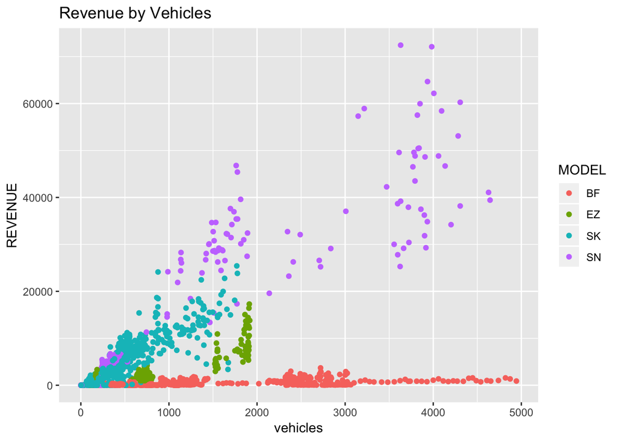

```r
rev_vehicle = data.b_nona %>% group_by(MODEL)

library(ggplot2)
qplot(vehicles, REVENUE, data=rev_vehicle,
 geom="point", stat = "identity", color = MODEL, main= "Revenue by Vehicles")
```

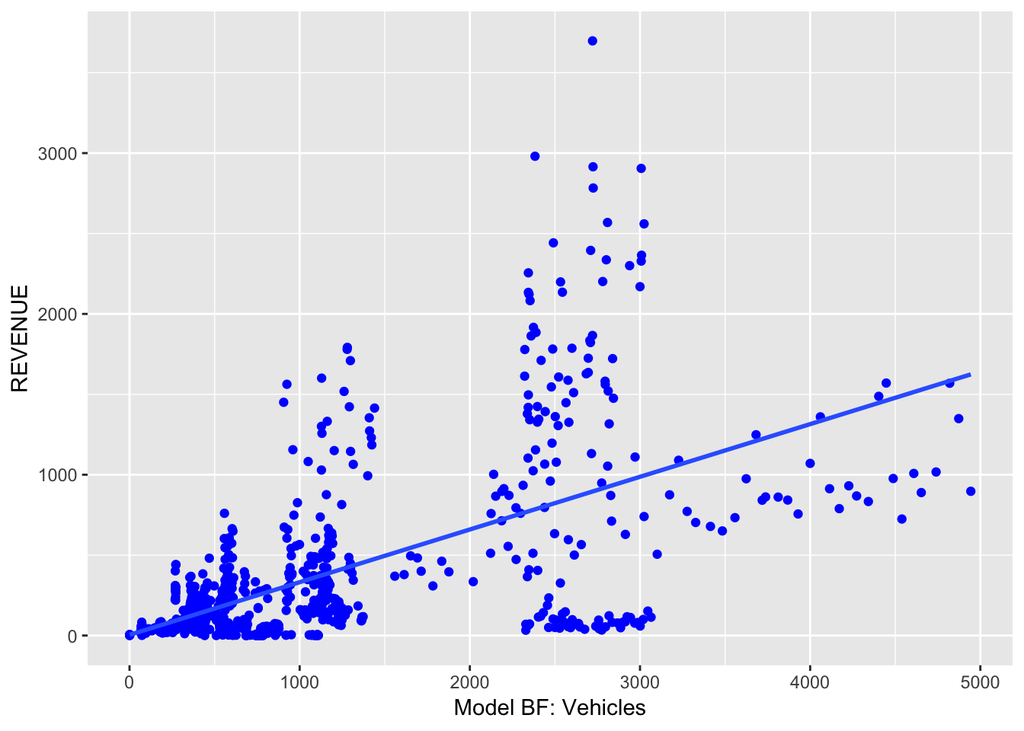

```r
#bf
bf<-data.b_nona %>% filter(MODEL=="BF")
#ez
ez<-data.b_nona %>% filter(MODEL=="EZ")
#sk
sk<-data.b_nona %>% filter(MODEL=="SK")
#sn
sn<-data.b_nona %>% filter(MODEL=="SN")

par(mfrow=c(1,4))
ggplot(data = bf, aes(x = vehicles, y = REVENUE)) +
  geom_point(color='blue') +
  geom_smooth(method = "lm", se = FALSE) + labs(x="Model BF: Vehicles")
```

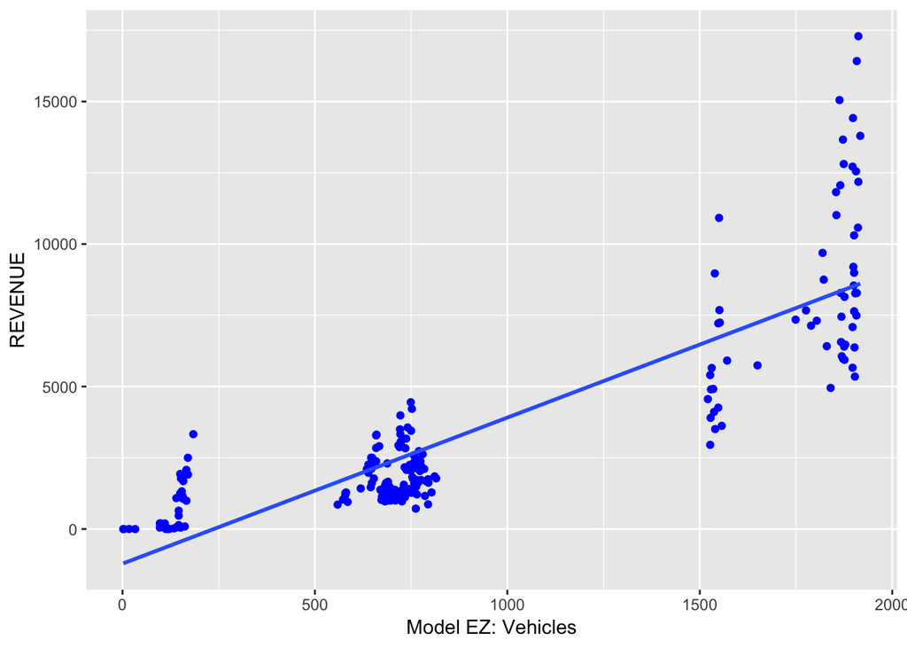

```r
ggplot(data = ez, aes(x = vehicles, y = REVENUE)) +
  geom_point(color='blue') +
  geom_smooth(method = "lm", se = FALSE)+ labs(x="Model EZ: Vehicles")
```

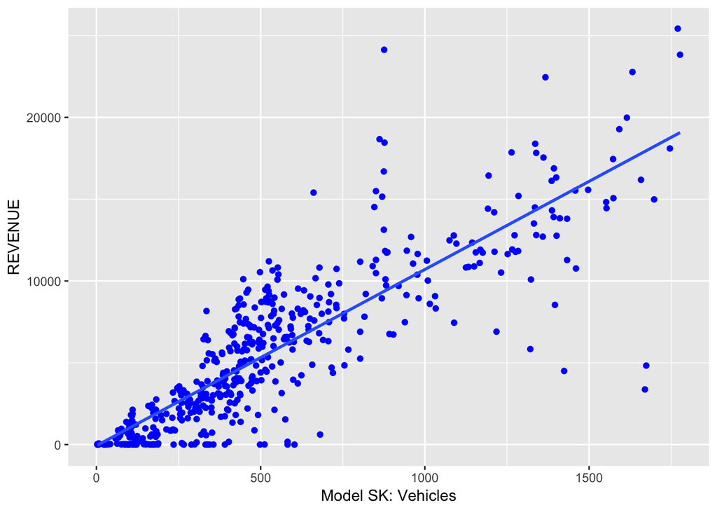

```r
ggplot(data = sk, aes(x = vehicles, y = REVENUE)) +
  geom_point(color='blue') +
  geom_smooth(method = "lm", se = FALSE) + labs(x="Model SK: Vehicles")
```

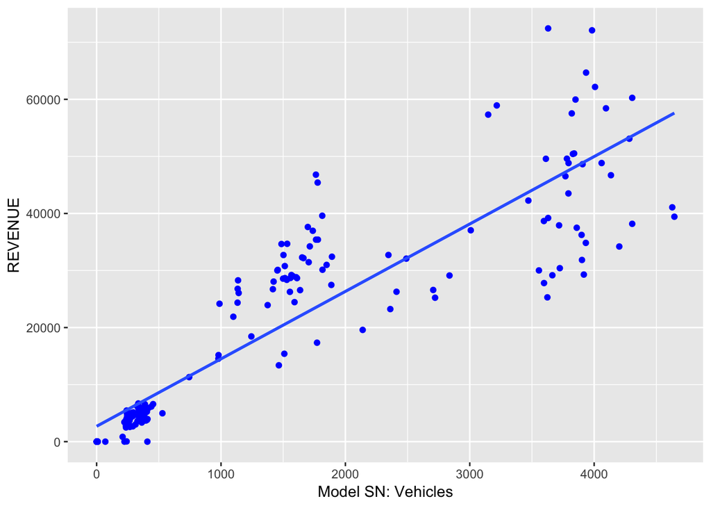

```r
ggplot(data = sn, aes(x = vehicles, y = REVENUE)) +
  geom_point(color='blue') +
  geom_smooth(method = "lm", se = FALSE)+ labs(x="Model SN: Vehicles")
```

5. Figure out per region, which of the regions saw an increase of per vehicle revnue, and by what percentage

```r
data.b_nona$DATE<-as.Date(data.b_nona$DATE)
data.b_nona$month<-format(data.b_nona$DATE,"%m")

index3<-which(data.b_nona$REVENUE==0)
data.b_nona$REVENUE[index3]<-NA
index4<-which(data.b_nona$vehicles==0)
data.b_nona$vehicles[index4]<-NA
data.b_nona<-na.omit(data.b_nona)

###total rev
total.rev<-as.data.frame(data.b_nona %>% group_by(Region,month) %>% summarise(totalrev=mean(na.omit(REVENUE))))
TotalRevenuePerRegion<-
as.data.frame(round((total.rev$totalrev[seq(0,8,2)]-total.rev$totalrev[seq(1,8,2)])/total.rev$totalrev[seq(1,8,2)],4)*100)
TotalRevenuePerRegion<-as.data.frame(paste(TotalRevenuePerRegion$`round((total.rev$totalrev[seq(0, 8, 2)] - total.rev$totalrev[seq(1, 8, 2)])/total.rev$totalrev[seq(1, 8, 2)], 4) * 100`,"%",sep=" "))

rownames(TotalRevenuePerRegion)<-c("Region 1", "Region 2", "Region 3", "Region 4")
colnames(TotalRevenuePerRegion)<-c("%Increase in total revenuee")

#####rev per car
rev.per.car.region<-as.data.frame(data.b_nona %>% group_by(Region,month) %>% summarise(rev.per.vehicle=mean(REVENUE/vehicles)))

#rownames(RevenuePerVehicleGrowth)<-c("Region 1", "Region 2", "Region 3", "Region 4")
#colnames(RevenuePerVehicleGrowth)<-c("Growth from Jun to Jul")

RevenuePerRegion<-as.data.frame(round((rev.per.car.region$rev.per.vehicle[seq(0,8,2)]-rev.per.car.region$rev.per.vehicle[seq(1,8,2)])/rev.per.car.region$rev.per.vehicle[seq(1,8,2)],4)*100)

RevenuePerRegion<-as.data.frame((paste(RevenuePerRegion$`round((rev.per.car.region$rev.per.vehicle[seq(0, 8, 2)] - rev.per.car.region$rev.per.vehicle[seq(1, 8, 2)])/rev.per.car.region$rev.per.vehicle[seq(1, 8, 2)], 4) * 100`, "%", sep="")))

rownames(RevenuePerRegion)<-c("Region 1", "Region 2", "Region 3", "Region 4")
colnames(RevenuePerRegion)<-c("%Increase in revenue per vehicle")
```

6. Try to figure out why, for question 5 (what are the numbers that’s changed for these regions? Models? S-ratio? Total rides? etc.)

```r
#changein s ratio
#jul
data.b2<-data.b_nona %>% filter(month=="07")%>% group_by(Region) %>% summarise(sratio=round(sum(SICK)/(sum(SICK)+sum(OPERATIONAL)),4))

#Jun
data.b3<-data.b_nona %>% filter(month=="06")%>% group_by(Region) %>% summarise(sratio=round(sum(SICK)/(sum(SICK)+sum(OPERATIONAL)),4))

#%change from jun to jul
SratioChange<-as.data.frame(round((data.b2$sratio-data.b3$sratio)/data.b3$sratio,4)*100)
SratioChange<-as.data.frame((paste(SratioChange$`round((data.b2$sratio - data.b3$sratio)/data.b3$sratio, 4) * 100`, "%", sep="")))
rownames(SratioChange)<-c("Region 1", "Region 2", "Region 3", "Region 4")
colnames(SratioChange)<-c("% Change in S-Ratio from Jun to Jul")
```

```r
#change in vehicle numbers
#jul
data.bb2<-data.b_nona %>% filter(month=="07")%>% group_by(Region) %>% summarise(num_vehicles=mean(vehicles))

#jun
data.bb3<-data.b_nona %>% filter(month=="06")%>% group_by(Region) %>% summarise(num_vehicles=mean(vehicles))

#%change from jun to jul
num_vehicles<-as.data.frame(round((data.bb2$num_vehicles-data.bb3$num_vehicles)/data.bb3$num_vehicles,4)*100)
num_vehicles<-as.data.frame(paste(num_vehicles$`round((data.bb2$num_vehicles - data.bb3$num_vehicles)/data.bb3$num_vehicles, 4) * 100`, "%", sep=""))
rownames(num_vehicles)<-c("Region 1", "Region 2", "Region 3", "Region 4")
colnames(num_vehicles)<-c("% Change in Avg Number of Vehicles from Jun to Jul")

finaltable<-cbind(TotalRevenuePerRegion,RevenuePerRegion,SratioChange,num_vehicles)
print(finaltable)
```

```
##          %Increase in total revenuee %Increase in revenue per vehicle
## Region 1                      68.8 %                           25.55%
## Region 2                    145.49 %                           67.87%
## Region 3                     41.84 %                           46.61%
## Region 4                     48.16 %                            5.91%
##          % Change in S-Ratio from Jun to Jul
## Region 1                               2.84%
## Region 2                             -21.56%
## Region 3                              10.87%
## Region 4                              -8.59%
##          % Change in Avg Number of Vehicles from Jun to Jul
## Region 1                                             -7.24%
## Region 2                                              6.39%
## Region 3                                            -33.21%
## Region 4                                             20.47%
```